# Chapter 11 functional analysis

Community functional capacity (GIFT framework): overall MCI differences, Wilcoxon/BH tests for element/function/domain contrasts, and compact visuals for the significant functions by sex.

**Note:** Load all required data objects including genome counts, metadata, GIFT database, and color schemes.

**Note:** Filter out sample EHI01340 and filter genome counts and GIFT community matrices to only include valid samples. This ensures consistency across all downstream analyses.

```r
sample_metadata <- sample_metadata %>% dplyr::filter(sample != "EHI01340")
valid_samples <- sample_metadata$sample

genome_counts_filt <- genome_counts_filt %>%
  dplyr::select(c(genome, tidyselect::any_of(valid_samples)))

# Note: GIFTs_elements_community, GIFTs_functions_community, and GIFTs_domains_community
# are created in the 'gift' chunk from the filtered genome_counts_filt, so they will
# automatically have the correct samples. No need to filter them here.
```

**Note:** Set factor levels for sex variable and define color schemes for plots. Filter genome counts to only include genomes that have GIFT annotations, and reset row names for downstream processing.

**Note:** Define helper function `transpose_and_convert` that performs a common transformation pattern: transposes a dataframe, converts row names to a column, and converts character columns to numeric. This function is reused throughout the analysis for consistent data reshaping.

**Note:** Aggregate GIFT functional annotations at multiple hierarchical levels: bundle-level to elements (compounds), elements to functions, and functions to domains (Biosynthesis, Degradation, Structural). Filter elements to remove those with zero abundance across all genomes. Calculate community-weighted average GIFTs per sample by normalizing genome counts to relative abundances and applying weighted aggregation.

## 11.1 MCI

**Note:** Calculate Mean Community Index (MCI) as the average of all function-level GIFTs per sample. Compute summary statistics (mean ± SD) by sex, test for normality using Shapiro-Wilk test, and perform Wilcoxon rank-sum test to compare MCI between sexes.

```r
GIFTs_functions_community %>%
  rowMeans() %>%
  as_tibble(., rownames = "sample") %>%
  left_join(sample_metadata, by = join_by(sample)) %>%
  group_by(sex) %>%
  summarise(MCI = mean(value), sd = sd(value), .groups = "drop")
```

```
## # A tibble: 3 × 3
##   sex      MCI     sd
##   <fct>  <dbl>  <dbl>
## 1 Male   0.216 0.0172
## 2 Female 0.200 0.0243
## 3 <NA>   0.226 0.0291
```

```r
MCI <- GIFTs_functions_community %>%
  rowMeans() %>%
  as_tibble(., rownames = "sample") %>%
  left_join(sample_metadata, by = join_by(sample))

shapiro.test(MCI$value)
```

```
##
##  Shapiro-Wilk normality test
##
## data:  MCI$value
## W = 0.98662, p-value = 0.6453
```

```r
if (length(unique(MCI$sex)) >= 2L && length(unique(MCI$value)) >= 2L) {
  wilcox.test(value ~ sex, data = MCI)
}
```

```
##
##  Wilcoxon rank sum exact test
##
## data:  value by sex
## W = 591, p-value = 0.006669
## alternative hypothesis: true location shift is not equal to 0
```

**Note:** Create a heatmap visualization of element-level GIFTs across all samples. Map element codes to readable element names and function codes to function names. Facet by function and sex to show patterns in functional capacity at the element level.

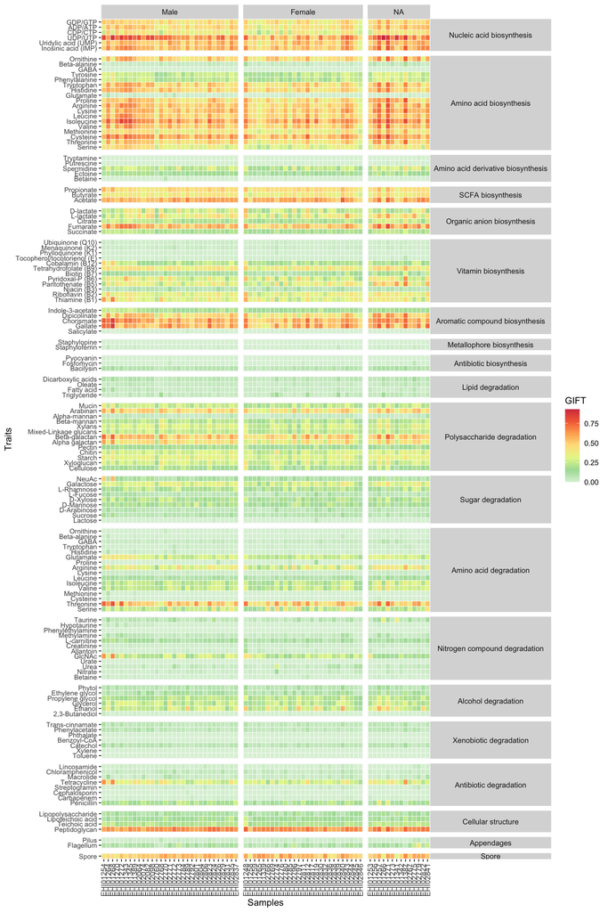

**Note:** Create a heatmap visualization of function-level GIFTs across all samples. Map function codes to readable function names and facet by sex to show differences in functional capacity at the function level.

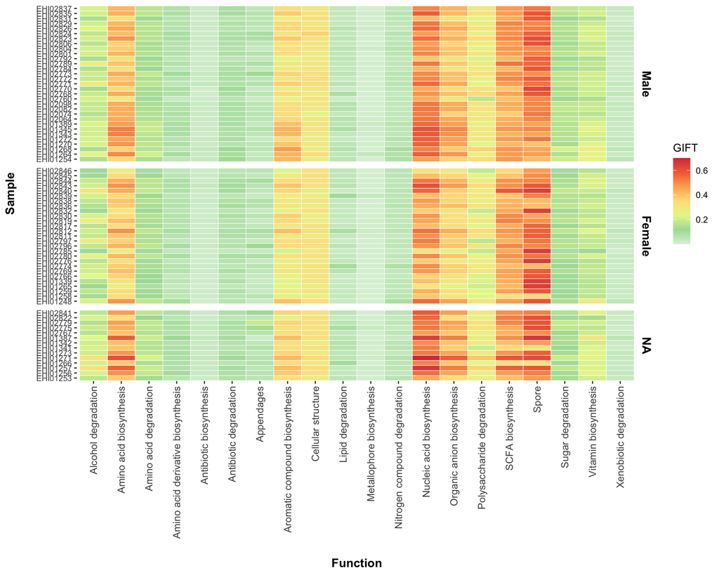

**Note:** Create a heatmap visualization of domain-level GIFTs (Biosynthesis, Degradation, Structural) across all samples. Facet by sex to show differences in functional capacity at the highest hierarchical level.

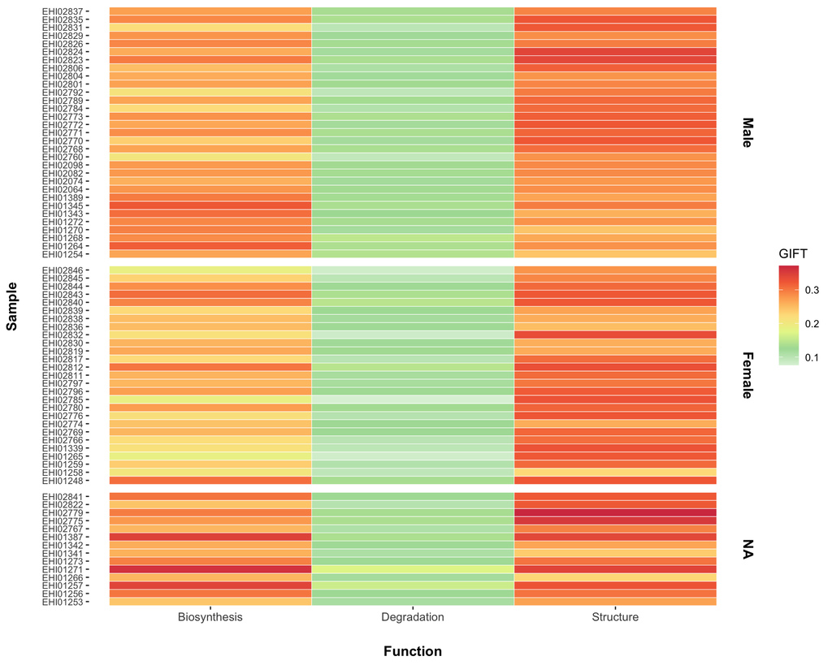

## 11.2 Wilcoxon

### 11.2.1 Community elements differences:

**Note:** Prepare element-level GIFT data by converting to dataframe format and joining with sample metadata (sex and broad_environment). This creates the base dataset for element-level differential analysis.

**Note:** Perform Wilcoxon rank-sum tests for each element-level GIFT between sexes. Apply Benjamini-Hochberg (BH) correction for multiple testing and filter to significant elements (p_adjust < 0.05). Create a lookup table mapping elements to functions. Filter element data to only significant elements, calculate mean abundances by sex, and compute difference table showing which sex has higher functional capacity for each element.

```
   Elements       Male      Female                                        Function
1     B0103 0.69177910 0.560537300               Nucleic acid biosynthesis_UDP/UTP
2     B0105 0.46116050 0.399974300               Nucleic acid biosynthesis_ADP/ATP
3     B0204 0.37548790 0.300740800                  Amino acid biosynthesis_Serine
4     B0206 0.60601820 0.540339700                Amino acid biosynthesis_Cysteine
5     B0207 0.40714250 0.358565700              Amino acid biosynthesis_Methionine
6     B0212 0.53270420 0.456655800                Amino acid biosynthesis_Arginine
7     B0601 0.20725980 0.180101500            Organic anion biosynthesis_Succinate
8     B0602 0.56365010 0.487367300             Organic anion biosynthesis_Fumarate
9     B0603 0.22724590 0.198884100              Organic anion biosynthesis_Citrate
10    B0805 0.19515240 0.157362900 Aromatic compound biosynthesis_Indole-3-acetate
11    D0103 0.04058481 0.031226720                        Lipid degradation_Oleate
12    D0203 0.32668240 0.292104900               Polysaccharide degradation_Starch
13    D0206 0.42934780 0.358623100       Polysaccharide degradation_Alpha galactan
14    D0213 0.25889110 0.214751300                Polysaccharide degradation_Mucin
15    D0508 0.02253498 0.016552670                   Amino acid degradation_Lysine
16    D0511 0.30194720 0.245140400                Amino acid degradation_Glutamate
17    D0609 0.12688980 0.096618700       Nitrogen compound degradation_L-carnitine
18    D0610 0.05437430 0.038411750       Nitrogen compound degradation_Methylamine
19    D0612 0.01453357 0.003058825       Nitrogen compound degradation_Hypotaurine
```

**Note:** Calculate log2 fold change for each significant element by comparing mean abundances between Male and Female samples. This quantifies the magnitude and direction of differences in functional capacity.

**Note:** Create boxplots with jittered points showing the distribution of each significant element-level GIFT by sex. Map element codes to readable element names and function names for better visualization. Use facet_wrap to display all significant elements in a grid layout.

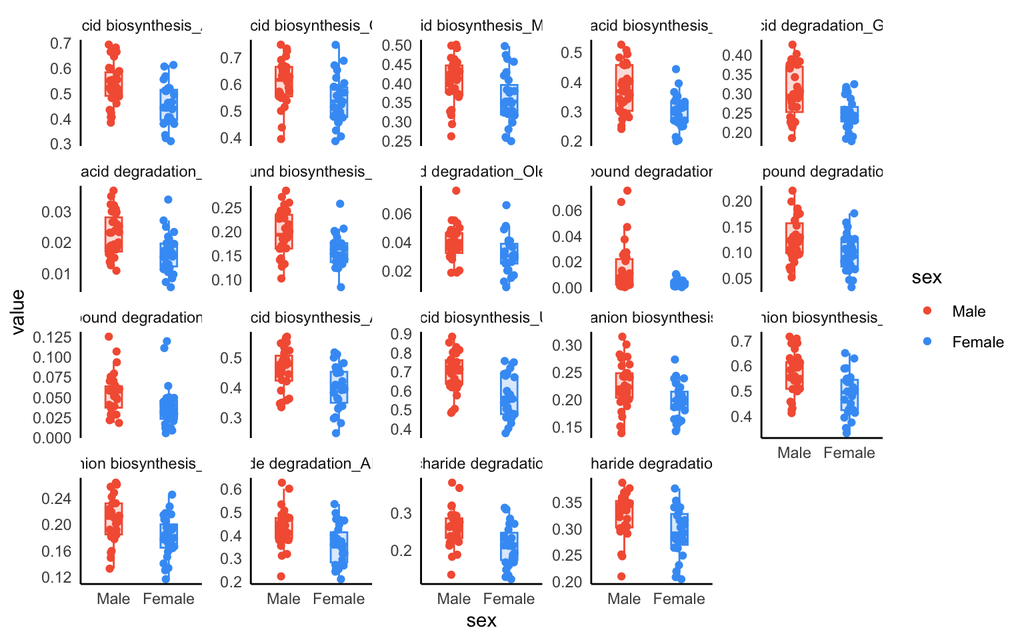

**Note:** Create a bar plot showing the mean difference in element-level GIFTs between sexes, ordered by function. Positive values indicate higher abundance in Females, negative values indicate higher abundance in Males. Color bars by which sex has higher functional capacity.

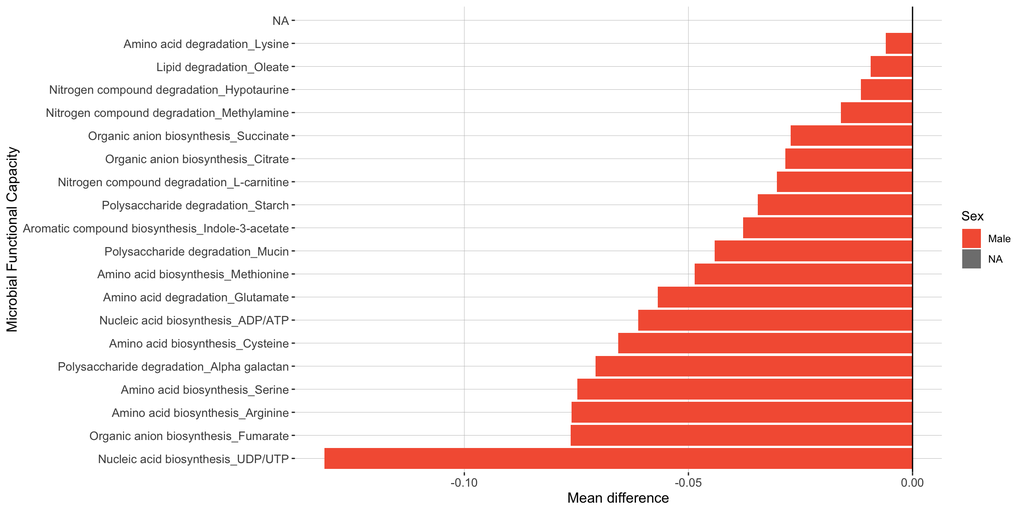

```r
difference_table %>%
  ggplot(aes(x=forcats::fct_reorder(Function,Difference), y=Difference, fill=group_color)) +
  geom_col() +
  scale_fill_manual(values=treatment_colors) +
  geom_hline(yintercept=0) +
  coord_flip()+
  theme(axis.text = element_text(size = 10),
        axis.title = element_text(size = 12),
        legend.position = "right",
        panel.background = element_blank(),
          panel.grid.major = element_line(size = 0.15, linetype = 'solid',
                                colour = "grey"))+
  xlab("Microbial Functional Capacity") +
  ylab("Mean difference")+
  labs(fill="Sex")
```

**Note:** Create a volcano plot combining statistical significance (-log10 adjusted p-value) and effect size (log2 fold change) for all significant elements. Color points by functional trait category and size by absolute mean difference. Add text labels for element names to identify the most significant and largest effect size differences.

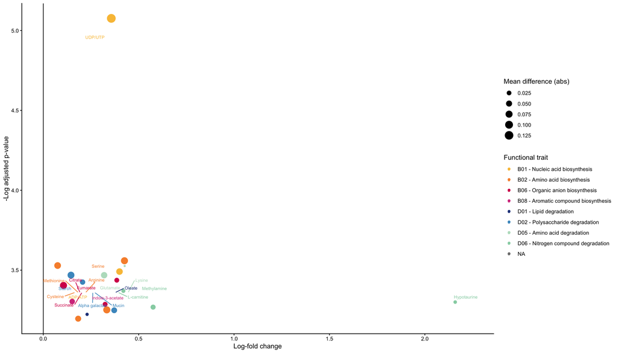

### 11.2.2 Community functions differences

**Note:** Prepare function-level GIFT data by converting to dataframe format and joining with sample metadata (sex and broad_environment). This creates the base dataset for function-level differential analysis.

```r
function_gift <- GIFTs_functions_community %>%
  as.data.frame() %>%
  rownames_to_column(., "sample") %>%
  left_join(sample_metadata %>% select(sample,sex,broad_environment), by=join_by(sample))
```

**Note:** Perform Wilcoxon rank-sum tests for each function-level GIFT between sexes. Apply Benjamini-Hochberg (BH) correction for multiple testing and filter to significant functions (p_adjust < 0.05). Join with function names for readability.

```r
unique_funct_db<- GIFT_db[c(3,4,5)] %>%
  distinct(Code_function, .keep_all = TRUE)

significant_functional <- function_gift %>%
    pivot_longer(-c(sample,sex,broad_environment), names_to = "trait", values_to = "value") %>%
    group_by(trait) %>%
    summarise(
      p_value = {
        vals <- value
        grp <- sex
        if (length(unique(stats::na.omit(grp))) < 2L || length(unique(stats::na.omit(vals))) < 2L) {
          NA_real_
        } else {
          tryCatch(stats::wilcox.test(vals ~ grp)$p.value, error = function(e) NA_real_)
        }
      },
      .groups = "drop"
    ) %>%
    mutate(p_adjust=p.adjust(p_value, method="BH")) %>%
    filter(p_adjust < 0.05)%>%
  left_join(.,unique_funct_db[c(1,3)],by = join_by(trait == Code_function))
```

**Note:** Filter function data to only significant functions, transpose for easier manipulation, and calculate mean abundances by sex. Join with function names to create a readable summary table of significant functional differences.

```r
function_gift_t <- function_gift  %>%
  select(-sex)  %>%
  transpose_and_convert("trait")

function_gift_filt <- function_gift_t %>%
  filter(trait %in% significant_functional$trait) %>%
  transpose_and_convert("sample")%>%
  left_join(., sample_metadata %>% select(sample,sex,broad_environment), by = join_by(sample)) %>%
  filter(!is.na(sex))

function_gift_filt %>%
  select(-c(sample,broad_environment)) %>%
  group_by(sex)  %>%
  summarise(across(everything(), mean), .groups = "drop")%>%
  transpose_and_convert("Code_function") %>%
  left_join(unique_funct_db[c(1,3)],by = join_by(Code_function))
```

```
  Code_function       Male     Female                       Function
1           B01 0.51040780 0.44677410      Nucleic acid biosynthesis
2           B02 0.41467140 0.37309600        Amino acid biosynthesis
3           B06 0.40301010 0.35207720     Organic anion biosynthesis
4           B08 0.34674810 0.30352230 Aromatic compound biosynthesis
5           B10 0.02299461 0.01916301        Antibiotic biosynthesis
6           D03 0.15508190 0.13586260              Sugar degradation
7           D09 0.08166883 0.06927333         Antibiotic degradation
```

**Note:** Create boxplots with jittered points showing the distribution of each significant function-level GIFT by sex. Map function codes to readable function names for better visualization. Use facet_wrap to display all significant functions in a grid layout.

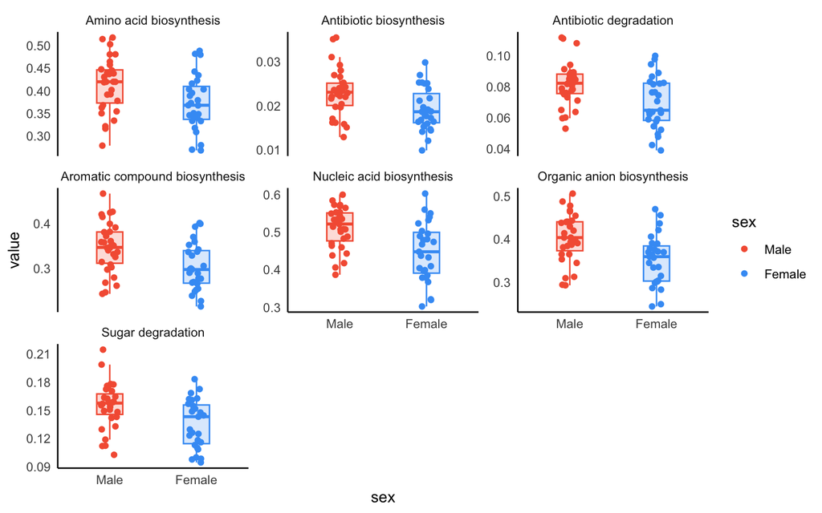

```r
function_gift_names <- function_gift_filt%>%
  select(-c(sex,broad_environment)) %>%
  transpose_and_convert("Code_function") %>%
  left_join(.,unique_funct_db[c(1,3)],by = join_by(Code_function))%>%
  select(Function, everything(), -Code_function)%>%
  transpose_and_convert("sample")%>%
  left_join(sample_metadata %>% select(sample,sex,broad_environment), by = join_by(sample))

# Optimize loop using pivot_longer and facet_wrap
function_gift_names %>%
  pivot_longer(-c(sample, sex, broad_environment), names_to = "function_name", values_to = "value") %>%
  ggplot(aes(x=sex, y=value, color = sex, fill=sex)) +
    geom_boxplot(alpha = 0.2, outlier.shape = NA, width = 0.3, show.legend = FALSE) +
    geom_jitter(width = 0.1, show.legend = TRUE) +
    scale_color_manual(values=treatment_colors)+
    scale_fill_manual(values=treatment_colors)+
    theme_minimal() +
    theme(
      axis.line = element_line(size = 0.5, linetype = "solid", colour = "black"),
      panel.grid.major = element_blank(),
      panel.grid.minor = element_blank(),
      panel.border = element_blank()) +
    facet_wrap(~function_name, scales = "free_y")
```

### 11.2.3 Community domains differences

**Note:** Prepare domain-level GIFT data by converting to dataframe format and joining with sample metadata (sex). This creates the base dataset for domain-level differential analysis.

```r
domain_gift <- GIFTs_domains_community %>%
  as.data.frame() %>%
  rownames_to_column(., "sample") %>%
  left_join(sample_metadata %>% select(sample,sex), by=join_by(sample))
```

**Note:** Perform Wilcoxon rank-sum tests for each domain-level GIFT (Biosynthesis, Degradation, Structural) between sexes. Apply Benjamini-Hochberg (BH) correction for multiple testing and filter to significant domains (p_adjust < 0.05).

```r
unique_domain_db<- GIFT_db[c(4)] %>%
  distinct(Domain, .keep_all = TRUE)

significant_domain <- domain_gift %>%
    pivot_longer(-c(sample,sex), names_to = "trait", values_to = "value") %>%
    group_by(trait) %>%
    summarise(
      p_value = {
        vals <- value
        grp <- sex
        if (length(unique(stats::na.omit(grp))) < 2L || length(unique(stats::na.omit(vals))) < 2L) {
          NA_real_
        } else {
          tryCatch(stats::wilcox.test(vals ~ grp)$p.value, error = function(e) NA_real_)
        }
      },
      .groups = "drop"
    ) %>%
    mutate(p_adjust=p.adjust(p_value, method="BH")) %>%
    filter(p_adjust < 0.05)
```

**Note:** Filter domain data to only significant domains, transpose for easier manipulation, and calculate mean abundances by sex. This creates a summary table showing which domains differ significantly between sexes.

```
   Code_domain      Male    Female
1 Biosynthesis 0.2706586 0.2442849
2  Degradation 0.1252927 0.1133303
```

**Note:** Create boxplots with jittered points showing the distribution of each significant domain-level GIFT by sex. Use facet_wrap to display all significant domains in a grid layout, allowing visual comparison of functional capacity differences at the highest hierarchical level.

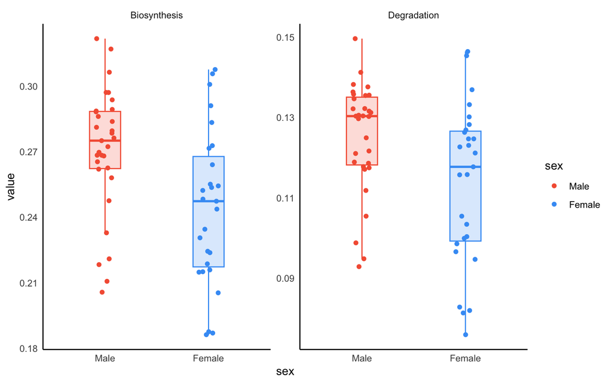